# Formação Cientista de Dados

### Projeto com Feedback 4

### Prevendo Customer Churn em Operadoras de Telecom

### Gabriel Quaiotti - Abr 2020

Customer Churn (ou Rotatividade de Clientes, em uma tradução livre) refere-se a uma decisão tomada pelo cliente sobre o término do relacionamento comercial. Refere-se também à perda de clientes. A fidelidade do cliente e a rotatividade de clientes sempre somam 100%. Se uma empresa tem uma taxa de fidelidade de 60%, então a taxa de perda de clientes é de 40%. De acordo com a regra de lucratividade do cliente 80/20, 20% dos clientes estão gerando 80% da receita. Portanto, é muito importante prever os usuários que provavelmente abandonarão o relacionamento comercial e os fatores que afetam as decisões do cliente.

Neste projeto, você deve prever o Customer Churn em uma Operadora de Telecom.

Os datasets de treino e de teste serão fornecidos para você em anexo a este projeto. Seu trabalho é criar um modelo de aprendizagem de máquina que possa prever se um cliente pode ou não cancelar seu plano e qual a probabilidade de isso ocorrer. O cabeçalho do dataset é uma descrição do tipo de informação em cada coluna.

Usando linguagem Python, recomendamos você criar um modelo de Regressão Logística, para extrair a informação se um cliente vai cancelar seu plano (Sim ou Não) e a probabilidade de uma opção ou outra.

```python
# Libraries
from pyspark.sql import SparkSession

from pyspark.sql.types import StructType
from pyspark.sql.types import StructField
from pyspark.sql.types import DoubleType
from pyspark.sql.types import IntegerType
from pyspark.sql.types import StringType

from pyspark.sql.functions import regexp_replace
from pyspark.sql.functions import col

from pyspark.ml.feature import StringIndexer

from seaborn import pairplot

from seaborn import FacetGrid
```

```python
# Spark Session - usado para trabalhar com o Spark
spSession = SparkSession.builder.master("local").appName("DSA-TELECOM-EXPLORE").getOrCreate()
```

# EXPLORE

```python
# Read train dataset as RDD
train_rdd = sc.textFile('../data/projeto4_telecom_treino.csv')
```

```python
# Check object type
type(train_rdd)
```

```
pyspark.rdd.RDD
```

```python
# View first 5 lines
train_rdd.take(5)
```

```
['"id","state","account_length","area_code","international_plan","voice_mail_plan","number_vmail_messages","total_day_minutes","total_day_calls","total_day_charge","total_eve_minutes","total_eve_calls","total_eve_charge","total_night_minutes","total_night_calls","total_night_charge","total_intl_minu…
 '"1","KS",128,"area_code_415","no","yes",25,265.1,110,45.07,197.4,99,16.78,244.7,91,11.01,10,3,2.7,1,"no"',
 '"2","OH",107,"area_code_415","no","yes",26,161.6,123,27.47,195.5,103,16.62,254.4,103,11.45,13.7,3,3.7,1,"no"',
 '"3","NJ",137,"area_code_415","no","no",0,243.4,114,41.38,121.2,110,10.3,162.6,104,7.32,12.2,5,3.29,0,"no"',
 '"4","OH",84,"area_code_408","yes","no",0,299.4,71,50.9,61.9,88,5.26,196.9,89,8.86,6.6,7,1.78,2,"no"']
```

```python
# Remove header and split by ','
header = train_rdd.first()
train_rdd2 = train_rdd.filter(lambda line: line != header).map(lambda line: line.split(","))
```

```python
# View first 5 lines
train_rdd2.take(5)
```

```
[['"1"',
  '"KS"',
  '128',
  '"area_code_415"',
  '"no"',
  '"yes"',
  '25',
  '265.1',
  '110',
  '45.07',
  '197.4',
  '99',
  '16.78',
  '244.7',
  '91',
  '11.01',
  '10',
  '3',
  '2.7',
  '1',
  '"no"'],
 ['"2"',
  '"OH"',
  '107',
  '"area_code_415"',
  '"no"',
  '"yes"',
  '26',
  '161.6',
  '123',
  '27.47',
  '195.5',
  '103',
  '16.62',
  '254.4',
  '103',
  '11.45',
  '13.7',
  '3',
  '3.7',
```

[output cut: 50 more lines]

```
  '0',
  '166.7',
  '113',
  '28.34',
  '148.3',
  '122',
  '12.61',
  '186.9',
  '121',
  '8.41',
  '10.1',
  '3',
  '2.73',
  '3',
  '"no"']]
```

```python
# Define the dataFrame columns
train_fields = [StructField("id", StringType(), True),
     StructField("state", StringType(), True),
     StructField("account_length", StringType(), True),
     StructField("area_code", StringType(), True),
     StructField("international_plan", StringType(), True),
     StructField("voice_mail_plan", StringType(), True),
     StructField("number_vmail_messages", StringType(), True),
     StructField("total_day_minutes", StringType(), True),
     StructField("total_day_calls", StringType(), True),
     StructField("total_day_charge", StringType(), True),
     StructField("total_eve_minutes", StringType(), True),
     StructField("total_eve_calls", StringType(), True),
     StructField("total_eve_charge", StringType(), True),
     StructField("total_night_minutes", StringType(), True),
     StructField("total_night_calls", StringType(), True),
     StructField("total_night_charge", StringType(), True),
     StructField("total_intl_minutes", StringType(), True),
     StructField("total_intl_calls", StringType(), True),
     StructField("total_intl_charge", StringType(), True),
     StructField("number_customer_service_calls", StringType(), True),
     StructField("churn", StringType(), True)]
```

```python
# Define the dataFrame schema
train_schema = StructType( train_fields )
```

```python
# Create dataFrame
train_ds = spSession.createDataFrame(train_rdd2, train_schema)
```

```python
# View first 5 lines
train_ds.toPandas().head()
```

|  | id | state | account_length | area_code | international_plan | voice_mail_plan | number_vmail_messages | total_day_minutes | total_day_calls | total_day_charge | ... | total_eve_calls | total_eve_charge | total_night_minutes | total_night_calls | total_night_charge | total_intl_minutes | total_intl_calls | total_intl_charge | number_customer_service_calls | churn |
| --- | --- | --- | --- | --- | --- | --- | --- | --- | --- | --- | --- | --- | --- | --- | --- | --- | --- | --- | --- | --- | --- |
| 0 | "1" | "KS" | 128 | "area_code_415" | "no" | "yes" | 25 | 265.1 | 110 | 45.07 | ... | 99 | 16.78 | 244.7 | 91 | 11.01 | 10 | 3 | 2.7 | 1 | "no" |
| 1 | "2" | "OH" | 107 | "area_code_415" | "no" | "yes" | 26 | 161.6 | 123 | 27.47 | ... | 103 | 16.62 | 254.4 | 103 | 11.45 | 13.7 | 3 | 3.7 | 1 | "no" |
| 2 | "3" | "NJ" | 137 | "area_code_415" | "no" | "no" | 0 | 243.4 | 114 | 41.38 | ... | 110 | 10.3 | 162.6 | 104 | 7.32 | 12.2 | 5 | 3.29 | 0 | "no" |
| 3 | "4" | "OH" | 84 | "area_code_408" | "yes" | "no" | 0 | 299.4 | 71 | 50.9 | ... | 88 | 5.26 | 196.9 | 89 | 8.86 | 6.6 | 7 | 1.78 | 2 | "no" |
| 4 | "5" | "OK" | 75 | "area_code_415" | "yes" | "no" | 0 | 166.7 | 113 | 28.34 | ... | 122 | 12.61 | 186.9 | 121 | 8.41 | 10.1 | 3 | 2.73 | 3 | "no" |

5 rows × 21 columns

```python
# Cast column types to Int or Double
train_ds = train_ds.withColumn("account_length", train_ds["account_length"].cast(DoubleType()))
train_ds = train_ds.withColumn("number_vmail_messages", train_ds["number_vmail_messages"].cast(IntegerType()))
train_ds = train_ds.withColumn("total_day_minutes", train_ds["total_day_minutes"].cast(DoubleType()))
train_ds = train_ds.withColumn("total_day_calls", train_ds["total_day_calls"].cast(IntegerType()))
train_ds = train_ds.withColumn("total_day_charge", train_ds["total_day_charge"].cast(DoubleType()))
train_ds = train_ds.withColumn("total_eve_minutes", train_ds["total_eve_minutes"].cast(DoubleType()))
train_ds = train_ds.withColumn("total_eve_calls", train_ds["total_eve_calls"].cast(IntegerType()))
train_ds = train_ds.withColumn("total_eve_charge", train_ds["total_eve_charge"].cast(DoubleType()))
train_ds = train_ds.withColumn("total_night_minutes", train_ds["total_night_minutes"].cast(DoubleType()))
train_ds = train_ds.withColumn("total_night_calls", train_ds["total_night_calls"].cast(IntegerType()))
train_ds = train_ds.withColumn("total_night_charge", train_ds["total_night_charge"].cast(DoubleType()))
train_ds = train_ds.withColumn("total_intl_minutes", train_ds["total_intl_minutes"].cast(DoubleType()))
train_ds = train_ds.withColumn("total_intl_calls", train_ds["total_intl_calls"].cast(IntegerType()))
train_ds = train_ds.withColumn("total_intl_charge", train_ds["total_intl_charge"].cast(DoubleType()))
train_ds = train_ds.withColumn("number_customer_service_calls", train_ds["number_customer_service_calls"].cast(IntegerType()))
```

[output not shown]

```python
# View first 5 lines
train_ds.toPandas().head()
```

|  | id | state | account_length | area_code | international_plan | voice_mail_plan | number_vmail_messages | total_day_minutes | total_day_calls | total_day_charge | ... | total_eve_calls | total_eve_charge | total_night_minutes | total_night_calls | total_night_charge | total_intl_minutes | total_intl_calls | total_intl_charge | number_customer_service_calls | churn |
| --- | --- | --- | --- | --- | --- | --- | --- | --- | --- | --- | --- | --- | --- | --- | --- | --- | --- | --- | --- | --- | --- |
| 0 | "1" | "KS" | 128.0 | "area_code_415" | "no" | "yes" | 25 | 265.1 | 110 | 45.07 | ... | 99 | 16.78 | 244.7 | 91 | 11.01 | 10.0 | 3 | 2.70 | 1 | "no" |
| 1 | "2" | "OH" | 107.0 | "area_code_415" | "no" | "yes" | 26 | 161.6 | 123 | 27.47 | ... | 103 | 16.62 | 254.4 | 103 | 11.45 | 13.7 | 3 | 3.70 | 1 | "no" |
| 2 | "3" | "NJ" | 137.0 | "area_code_415" | "no" | "no" | 0 | 243.4 | 114 | 41.38 | ... | 110 | 10.30 | 162.6 | 104 | 7.32 | 12.2 | 5 | 3.29 | 0 | "no" |
| 3 | "4" | "OH" | 84.0 | "area_code_408" | "yes" | "no" | 0 | 299.4 | 71 | 50.90 | ... | 88 | 5.26 | 196.9 | 89 | 8.86 | 6.6 | 7 | 1.78 | 2 | "no" |
| 4 | "5" | "OK" | 75.0 | "area_code_415" | "yes" | "no" | 0 | 166.7 | 113 | 28.34 | ... | 122 | 12.61 | 186.9 | 121 | 8.41 | 10.1 | 3 | 2.73 | 3 | "no" |

5 rows × 21 columns

```python
# Replace values into String columns
train_ds = train_ds.withColumn('id', regexp_replace(col('id'), '"', '') )

train_ds = train_ds.withColumn('international_plan', regexp_replace(col('international_plan'), 'no', '0') )
train_ds = train_ds.withColumn('international_plan', regexp_replace(col('international_plan'), 'yes', '1') )
train_ds = train_ds.withColumn('international_plan', regexp_replace(col('international_plan'), '"', '') )

train_ds = train_ds.withColumn('voice_mail_plan', regexp_replace(col('voice_mail_plan'), 'no', '0') )
train_ds = train_ds.withColumn('voice_mail_plan', regexp_replace(col('voice_mail_plan'), 'yes', '1') )
train_ds = train_ds.withColumn('voice_mail_plan', regexp_replace(col('voice_mail_plan'), '"', '') )

train_ds = train_ds.withColumn('area_code', regexp_replace(col('area_code'), 'area_code_', '') )

train_ds = train_ds.withColumn('churn', regexp_replace(col('churn'), 'no', '0') )
train_ds = train_ds.withColumn('churn', regexp_replace(col('churn'), 'yes', '1') )
train_ds = train_ds.withColumn('churn', regexp_replace(col('churn'), '"', '') )
```

```python
# View first 5 lines
train_ds.toPandas().head()
```

|  | id | state | account_length | area_code | international_plan | voice_mail_plan | number_vmail_messages | total_day_minutes | total_day_calls | total_day_charge | ... | total_eve_calls | total_eve_charge | total_night_minutes | total_night_calls | total_night_charge | total_intl_minutes | total_intl_calls | total_intl_charge | number_customer_service_calls | churn |
| --- | --- | --- | --- | --- | --- | --- | --- | --- | --- | --- | --- | --- | --- | --- | --- | --- | --- | --- | --- | --- | --- |
| 0 | 1 | "KS" | 128.0 | "415" | 0 | 1 | 25 | 265.1 | 110 | 45.07 | ... | 99 | 16.78 | 244.7 | 91 | 11.01 | 10.0 | 3 | 2.70 | 1 | 0 |
| 1 | 2 | "OH" | 107.0 | "415" | 0 | 1 | 26 | 161.6 | 123 | 27.47 | ... | 103 | 16.62 | 254.4 | 103 | 11.45 | 13.7 | 3 | 3.70 | 1 | 0 |
| 2 | 3 | "NJ" | 137.0 | "415" | 0 | 0 | 0 | 243.4 | 114 | 41.38 | ... | 110 | 10.30 | 162.6 | 104 | 7.32 | 12.2 | 5 | 3.29 | 0 | 0 |
| 3 | 4 | "OH" | 84.0 | "408" | 1 | 0 | 0 | 299.4 | 71 | 50.90 | ... | 88 | 5.26 | 196.9 | 89 | 8.86 | 6.6 | 7 | 1.78 | 2 | 0 |
| 4 | 5 | "OK" | 75.0 | "415" | 1 | 0 | 0 | 166.7 | 113 | 28.34 | ... | 122 | 12.61 | 186.9 | 121 | 8.41 | 10.1 | 3 | 2.73 | 3 | 0 |

5 rows × 21 columns

```python
# Cast column types to Int
train_ds = train_ds.withColumn("id", train_ds["id"].cast(IntegerType()))
train_ds = train_ds.withColumn("international_plan", train_ds["international_plan"].cast(IntegerType()))
train_ds = train_ds.withColumn("voice_mail_plan", train_ds["voice_mail_plan"].cast(IntegerType()))
train_ds = train_ds.withColumn("churn", train_ds["churn"].cast(IntegerType()))
```

```python
# View first 5 lines
train_ds.toPandas().head()
```

|  | id | state | account_length | area_code | international_plan | voice_mail_plan | number_vmail_messages | total_day_minutes | total_day_calls | total_day_charge | ... | total_eve_calls | total_eve_charge | total_night_minutes | total_night_calls | total_night_charge | total_intl_minutes | total_intl_calls | total_intl_charge | number_customer_service_calls | churn |
| --- | --- | --- | --- | --- | --- | --- | --- | --- | --- | --- | --- | --- | --- | --- | --- | --- | --- | --- | --- | --- | --- |
| 0 | 1 | "KS" | 128.0 | "415" | 0 | 1 | 25 | 265.1 | 110 | 45.07 | ... | 99 | 16.78 | 244.7 | 91 | 11.01 | 10.0 | 3 | 2.70 | 1 | 0 |
| 1 | 2 | "OH" | 107.0 | "415" | 0 | 1 | 26 | 161.6 | 123 | 27.47 | ... | 103 | 16.62 | 254.4 | 103 | 11.45 | 13.7 | 3 | 3.70 | 1 | 0 |
| 2 | 3 | "NJ" | 137.0 | "415" | 0 | 0 | 0 | 243.4 | 114 | 41.38 | ... | 110 | 10.30 | 162.6 | 104 | 7.32 | 12.2 | 5 | 3.29 | 0 | 0 |
| 3 | 4 | "OH" | 84.0 | "408" | 1 | 0 | 0 | 299.4 | 71 | 50.90 | ... | 88 | 5.26 | 196.9 | 89 | 8.86 | 6.6 | 7 | 1.78 | 2 | 0 |
| 4 | 5 | "OK" | 75.0 | "415" | 1 | 0 | 0 | 166.7 | 113 | 28.34 | ... | 122 | 12.61 | 186.9 | 121 | 8.41 | 10.1 | 3 | 2.73 | 3 | 0 |

5 rows × 21 columns

```python
# Verify if there are null values
for i in train_ds.columns:
    print( train_ds.where(col(i).isNull()).count() )
```

```
0
0
0
0
0
0
0
0
0
0
0
0
0
0
0
0
0
0
0
0
0
```

```python
# Check values into 'state' column
train_ds.select('state').distinct().sort('state').collect()
```

```
[Row(state='"AK"'),
 Row(state='"AL"'),
 Row(state='"AR"'),
 Row(state='"AZ"'),
 Row(state='"CA"'),
 Row(state='"CO"'),
 Row(state='"CT"'),
 Row(state='"DC"'),
 Row(state='"DE"'),
 Row(state='"FL"'),
 Row(state='"GA"'),
 Row(state='"HI"'),
 Row(state='"IA"'),
 Row(state='"ID"'),
 Row(state='"IL"'),
 Row(state='"IN"'),
 Row(state='"KS"'),
 Row(state='"KY"'),
 Row(state='"LA"'),
 Row(state='"MA"'),
 Row(state='"MD"'),
 Row(state='"ME"'),
 Row(state='"MI"'),
 Row(state='"MN"'),
 Row(state='"MO"'),
 Row(state='"MS"'),
 Row(state='"MT"'),
 Row(state='"NC"'),
 Row(state='"ND"'),
 Row(state='"NE"'),
 Row(state='"NH"'),
 Row(state='"NJ"'),
 Row(state='"NM"'),
 Row(state='"NV"'),
 Row(state='"NY"'),
 Row(state='"OH"'),
 Row(state='"OK"'),
 Row(state='"OR"'),
 Row(state='"PA"'),
 Row(state='"RI"'),
 Row(state='"SC"'),
 Row(state='"SD"'),
 Row(state='"TN"'),
 Row(state='"TX"'),
 Row(state='"UT"'),
 Row(state='"VA"'),
 Row(state='"VT"'),
 Row(state='"WA"'),
 Row(state='"WI"'),
 Row(state='"WV"'),
 Row(state='"WY"')]
```

```python
# Factorize 'state' column
# Create 'state_id' column
# Save indexer to use on test
# Drop 'state' column
indexer = StringIndexer(inputCol="state", outputCol="state_id").fit(train_ds)
train_ds = indexer.transform(train_ds)
indexer.write().overwrite().save('../obj/state_column_indexer.obj')
train_ds = train_ds.drop('state')
train_ds.toPandas().head()
```

|  | id | account_length | area_code | international_plan | voice_mail_plan | number_vmail_messages | total_day_minutes | total_day_calls | total_day_charge | total_eve_minutes | ... | total_eve_charge | total_night_minutes | total_night_calls | total_night_charge | total_intl_minutes | total_intl_calls | total_intl_charge | number_customer_service_calls | churn | state_id |
| --- | --- | --- | --- | --- | --- | --- | --- | --- | --- | --- | --- | --- | --- | --- | --- | --- | --- | --- | --- | --- | --- |
| 0 | 1 | 128.0 | "415" | 0 | 1 | 25 | 265.1 | 110 | 45.07 | 197.4 | ... | 16.78 | 244.7 | 91 | 11.01 | 10.0 | 3 | 2.70 | 1 | 0 | 17.0 |
| 1 | 2 | 107.0 | "415" | 0 | 1 | 26 | 161.6 | 123 | 27.47 | 195.5 | ... | 16.62 | 254.4 | 103 | 11.45 | 13.7 | 3 | 3.70 | 1 | 0 | 5.0 |
| 2 | 3 | 137.0 | "415" | 0 | 0 | 0 | 243.4 | 114 | 41.38 | 121.2 | ... | 10.30 | 162.6 | 104 | 7.32 | 12.2 | 5 | 3.29 | 0 | 0 | 19.0 |
| 3 | 4 | 84.0 | "408" | 1 | 0 | 0 | 299.4 | 71 | 50.90 | 61.9 | ... | 5.26 | 196.9 | 89 | 8.86 | 6.6 | 7 | 1.78 | 2 | 0 | 5.0 |
| 4 | 5 | 75.0 | "415" | 1 | 0 | 0 | 166.7 | 113 | 28.34 | 148.3 | ... | 12.61 | 186.9 | 121 | 8.41 | 10.1 | 3 | 2.73 | 3 | 0 | 34.0 |

5 rows × 21 columns

```python
# Check values into 'area_code' column
train_ds.select('area_code').distinct().sort('area_code').collect()
```

```
[Row(area_code='"408"'), Row(area_code='"415"'), Row(area_code='"510"')]
```

```python
# Factorize 'area_code' column
# Create 'area_code_id' column
# Save indexer to use on test
# Drop 'area_code' column
indexer = StringIndexer(inputCol="area_code", outputCol="area_code_id").fit(train_ds)
train_ds = indexer.transform(train_ds)
indexer.write().overwrite().save('../obj/area_code_column_indexer.obj')
train_ds = train_ds.drop('area_code')
train_ds.toPandas().head()
```

|  | id | account_length | international_plan | voice_mail_plan | number_vmail_messages | total_day_minutes | total_day_calls | total_day_charge | total_eve_minutes | total_eve_calls | ... | total_night_minutes | total_night_calls | total_night_charge | total_intl_minutes | total_intl_calls | total_intl_charge | number_customer_service_calls | churn | state_id | area_code_id |
| --- | --- | --- | --- | --- | --- | --- | --- | --- | --- | --- | --- | --- | --- | --- | --- | --- | --- | --- | --- | --- | --- |
| 0 | 1 | 128.0 | 0 | 1 | 25 | 265.1 | 110 | 45.07 | 197.4 | 99 | ... | 244.7 | 91 | 11.01 | 10.0 | 3 | 2.70 | 1 | 0 | 17.0 | 0.0 |
| 1 | 2 | 107.0 | 0 | 1 | 26 | 161.6 | 123 | 27.47 | 195.5 | 103 | ... | 254.4 | 103 | 11.45 | 13.7 | 3 | 3.70 | 1 | 0 | 5.0 | 0.0 |
| 2 | 3 | 137.0 | 0 | 0 | 0 | 243.4 | 114 | 41.38 | 121.2 | 110 | ... | 162.6 | 104 | 7.32 | 12.2 | 5 | 3.29 | 0 | 0 | 19.0 | 0.0 |
| 3 | 4 | 84.0 | 1 | 0 | 0 | 299.4 | 71 | 50.90 | 61.9 | 88 | ... | 196.9 | 89 | 8.86 | 6.6 | 7 | 1.78 | 2 | 0 | 5.0 | 2.0 |
| 4 | 5 | 75.0 | 1 | 0 | 0 | 166.7 | 113 | 28.34 | 148.3 | 122 | ... | 186.9 | 121 | 8.41 | 10.1 | 3 | 2.73 | 3 | 0 | 34.0 | 0.0 |

5 rows × 21 columns

```python
train_ds.toPandas().describe()
```

|  | id | account_length | international_plan | voice_mail_plan | number_vmail_messages | total_day_minutes | total_day_calls | total_day_charge | total_eve_minutes | total_eve_calls | ... | total_night_minutes | total_night_calls | total_night_charge | total_intl_minutes | total_intl_calls | total_intl_charge | number_customer_service_calls | churn | state_id | area_code_id |
| --- | --- | --- | --- | --- | --- | --- | --- | --- | --- | --- | --- | --- | --- | --- | --- | --- | --- | --- | --- | --- | --- |
| count | 3333.00000 | 3333.000000 | 3333.000000 | 3333.000000 | 3333.000000 | 3333.000000 | 3333.000000 | 3333.000000 | 3333.000000 | 3333.000000 | ... | 3333.000000 | 3333.000000 | 3333.000000 | 3333.000000 | 3333.000000 | 3333.000000 | 3333.000000 | 3333.000000 | 3333.000000 | 3333.000000 |
| mean | 1667.00000 | 101.064806 | 0.096910 | 0.276628 | 8.099010 | 179.775098 | 100.435644 | 30.562307 | 200.980348 | 100.114311 | ... | 200.872037 | 100.107711 | 9.039325 | 10.237294 | 4.479448 | 2.764581 | 1.562856 | 0.144914 | 22.536454 | 0.754875 |
| std | 962.29855 | 39.822106 | 0.295879 | 0.447398 | 13.688365 | 54.467389 | 20.069084 | 9.259435 | 50.713844 | 19.922625 | ... | 50.573847 | 19.568609 | 2.275873 | 2.791840 | 2.461214 | 0.753773 | 1.315491 | 0.352067 | 14.544121 | 0.829515 |
| min | 1.00000 | 1.000000 | 0.000000 | 0.000000 | 0.000000 | 0.000000 | 0.000000 | 0.000000 | 0.000000 | 0.000000 | ... | 23.200000 | 33.000000 | 1.040000 | 0.000000 | 0.000000 | 0.000000 | 0.000000 | 0.000000 | 0.000000 | 0.000000 |
| 25% | 834.00000 | 74.000000 | 0.000000 | 0.000000 | 0.000000 | 143.700000 | 87.000000 | 24.430000 | 166.600000 | 87.000000 | ... | 167.000000 | 87.000000 | 7.520000 | 8.500000 | 3.000000 | 2.300000 | 1.000000 | 0.000000 | 10.000000 | 0.000000 |
| 50% | 1667.00000 | 101.000000 | 0.000000 | 0.000000 | 0.000000 | 179.400000 | 101.000000 | 30.500000 | 201.400000 | 100.000000 | ... | 201.200000 | 100.000000 | 9.050000 | 10.300000 | 4.000000 | 2.780000 | 1.000000 | 0.000000 | 22.000000 | 1.000000 |
| 75% | 2500.00000 | 127.000000 | 0.000000 | 1.000000 | 20.000000 | 216.400000 | 114.000000 | 36.790000 | 235.300000 | 114.000000 | ... | 235.300000 | 113.000000 | 10.590000 | 12.100000 | 6.000000 | 3.270000 | 2.000000 | 0.000000 | 35.000000 | 2.000000 |
| max | 3333.00000 | 243.000000 | 1.000000 | 1.000000 | 51.000000 | 350.800000 | 165.000000 | 59.640000 | 363.700000 | 170.000000 | ... | 395.000000 | 175.000000 | 17.770000 | 20.000000 | 20.000000 | 5.400000 | 9.000000 | 1.000000 | 50.000000 | 2.000000 |

8 rows × 21 columns

```python
# Get column names
train_ds.columns
```

```
['id',
 'account_length',
 'international_plan',
 'voice_mail_plan',
 'number_vmail_messages',
 'total_day_minutes',
 'total_day_calls',
 'total_day_charge',
 'total_eve_minutes',
 'total_eve_calls',
 'total_eve_charge',
 'total_night_minutes',
 'total_night_calls',
 'total_night_charge',
 'total_intl_minutes',
 'total_intl_calls',
 'total_intl_charge',
 'number_customer_service_calls',
 'churn',
 'state_id',
 'area_code_id']
```

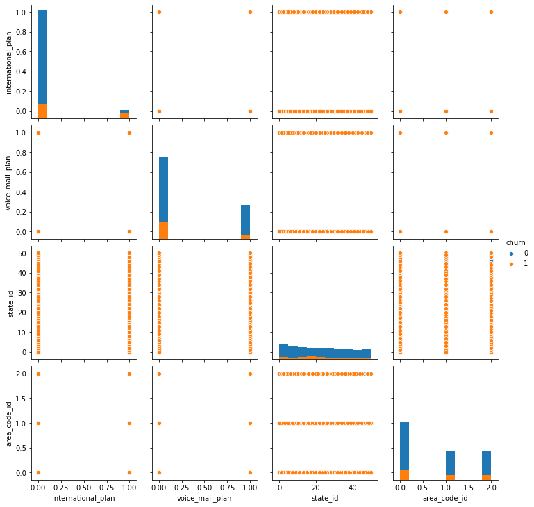

```python
# Explore
pairplot(
    train_ds[
        'international_plan',
        'voice_mail_plan',
        'state_id',
        'area_code_id',
        'churn'
    ].toPandas(),
    hue='churn',
    diag_kind='hist')
```

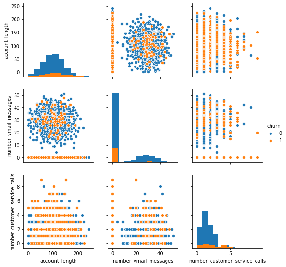

```python
# Explore
pairplot(
    train_ds[
        'account_length',
        'number_vmail_messages',
        'number_customer_service_calls',
        'churn'
    ].toPandas(),
    hue='churn',
    diag_kind='hist')
```

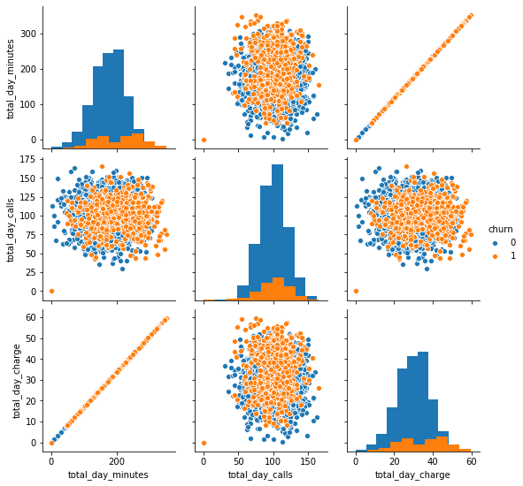

```python
# Explore
pairplot(
    train_ds[
        'total_day_minutes',
        'total_day_calls',
        'total_day_charge',
        'churn'
    ].toPandas(),
    hue='churn',
    diag_kind='hist')
```

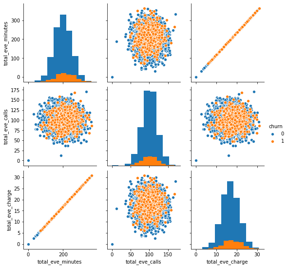

```python
# Explore
pairplot(
    train_ds[
        'total_eve_minutes',
        'total_eve_calls',
        'total_eve_charge',
        'churn'
    ].toPandas(),
    hue='churn',
    diag_kind='hist')
```

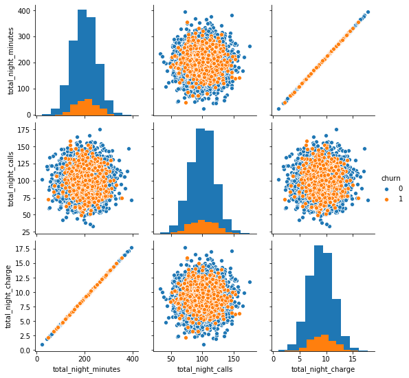

```python
# Explore
pairplot(
    train_ds[
        'total_night_minutes',
        'total_night_calls',
        'total_night_charge',
        'churn'
    ].toPandas(),
    hue='churn',
    diag_kind='hist')
```

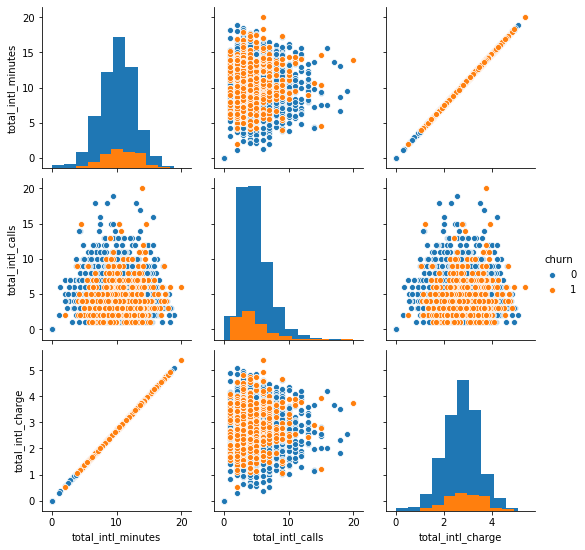

```python
# Explore
pairplot(
    train_ds[
        'total_intl_minutes',
        'total_intl_calls',
        'total_intl_charge',
        'churn'
    ].toPandas(),
    hue='churn',
    diag_kind='hist')
```

```python
# Trying to improve the model
train_ds = train_ds.withColumn("number_customer_service_calls", train_ds["number_customer_service_calls"] ** 2)
train_ds = train_ds.withColumn("total_intl_calls", train_ds["total_intl_calls"] ** 2)
```

```python
train_ds
```

```
DataFrame[id: int, account_length: double, international_plan: int, voice_mail_plan: int, number_vmail_messages: int, total_day_minutes: double, total_day_calls: int, total_day_charge: double, total_eve_minutes: double, total_eve_calls: int, total_eve_charge: double, total_night_minutes: double, tot…
```

```python
# Save dataFrame to CSV file
train_ds.toPandas().to_csv('../dataset/df_transformed.csv', index=False)
```